## Bob Ross The Joy of Painting Case Study (Review)

### Read elements data

```r
all_elements = read_csv("../../data/elements-by-episode.csv")

all_elements
```

```
## # A tibble: 403 × 69
##    EPISODE TITLE   APPLE_FRAME AURORA_BOREALIS  BARN BEACH  BOAT BRIDGE BUILDING
##    <chr>   <chr>         <dbl>           <dbl> <dbl> <dbl> <dbl>  <dbl>    <dbl>
##  1 S01E01  "\"A W…           0               0     0     0     0      0        0
##  2 S01E02  "\"MT.…           0               0     0     0     0      0        0
##  3 S01E03  "\"EBO…           0               0     0     0     0      0        0
##  4 S01E04  "\"WIN…           0               0     0     0     0      0        0
##  5 S01E05  "\"QUI…           0               0     0     0     0      0        0
##  6 S01E06  "\"WIN…           0               0     0     0     0      0        0
##  7 S01E07  "\"AUT…           0               0     0     0     0      0        0
##  8 S01E08  "\"PEA…           0               0     0     0     0      0        0
##  9 S01E09  "\"SEA…           0               0     0     1     0      0        0
## 10 S01E10  "\"MOU…           0               0     0     0     0      0        0
## # ℹ 393 more rows
## # ℹ 60 more variables: BUSHES <dbl>, CABIN <dbl>, CACTUS <dbl>,
## #   CIRCLE_FRAME <dbl>, CIRRUS <dbl>, CLIFF <dbl>, CLOUDS <dbl>, CONIFER <dbl>,
## #   CUMULUS <dbl>, DECIDUOUS <dbl>, DIANE_ANDRE <dbl>, DOCK <dbl>,
## #   DOUBLE_OVAL_FRAME <dbl>, FARM <dbl>, FENCE <dbl>, FIRE <dbl>,
## #   FLORIDA_FRAME <dbl>, FLOWERS <dbl>, FOG <dbl>, FRAMED <dbl>, GRASS <dbl>,
## #   GUEST <dbl>, HALF_CIRCLE_FRAME <dbl>, HALF_OVAL_FRAME <dbl>, HILLS <dbl>, …
```

> Are the titles unique?

```r
all_elements %>%
  count(TITLE) %>%
  filter(n > 1)
```

```
## # A tibble: 2 × 2
##   TITLE                        n
##   <chr>                    <int>
## 1 "\"LAKESIDE CABIN\""         2
## 2 "\"MOUNTAIN WATERFALL\""     2
```

- No, two titles were repeated twice each.

> Find episodes with a repeated title

```r
repeated_titles = all_elements %>%
  count(TITLE) %>%
  filter(n > 1) %>%
  pull(TITLE)

all_elements %>%
  filter(TITLE %in% repeated_titles) %>%
  select(EPISODE, TITLE)
```

```
## # A tibble: 4 × 2
##   EPISODE TITLE
##   <chr>   <chr>
## 1 S02E12  "\"MOUNTAIN WATERFALL\""
## 2 S05E01  "\"MOUNTAIN WATERFALL\""
## 3 S08E02  "\"LAKESIDE CABIN\""
## 4 S10E13  "\"LAKESIDE CABIN\""
```

#### semi-join() solution

```r
repeated_titles_df = all_elements %>%
  count(TITLE) %>%
  filter(n > 1)

all_elements %>%
  semi_join(repeated_titles_df, join_by(TITLE)) %>%
  select(EPISODE, TITLE)
```

```
## # A tibble: 4 × 2
##   EPISODE TITLE
##   <chr>   <chr>
## 1 S02E12  "\"MOUNTAIN WATERFALL\""
## 2 S05E01  "\"MOUNTAIN WATERFALL\""
## 3 S08E02  "\"LAKESIDE CABIN\""
## 4 S10E13  "\"LAKESIDE CABIN\""
```

> Create a data frame with only Bob Ross hosted paintings and no host or frame variables.

```r
painting_elements = all_elements %>%
  filter(GUEST == 0) %>%
  select(-GUEST, -DIANE_ANDRE, -STEVE_ROSS, -FRAMED,
         -contains("_FRAME"))

painting_elements
```

```
## # A tibble: 381 × 50
##    EPISODE TITLE  AURORA_BOREALIS  BARN BEACH  BOAT BRIDGE BUILDING BUSHES CABIN
##    <chr>   <chr>            <dbl> <dbl> <dbl> <dbl>  <dbl>    <dbl>  <dbl> <dbl>
##  1 S01E01  "\"A …               0     0     0     0      0        0      1     0
##  2 S01E02  "\"MT…               0     0     0     0      0        0      0     1
##  3 S01E03  "\"EB…               0     0     0     0      0        0      0     1
##  4 S01E04  "\"WI…               0     0     0     0      0        0      1     0
##  5 S01E05  "\"QU…               0     0     0     0      0        0      0     0
##  6 S01E06  "\"WI…               0     0     0     0      0        0      0     1
##  7 S01E07  "\"AU…               0     0     0     0      0        0      0     0
##  8 S01E08  "\"PE…               0     0     0     0      0        0      1     0
##  9 S01E09  "\"SE…               0     0     1     0      0        0      0     0
## 10 S01E10  "\"MO…               0     0     0     0      0        0      1     0
## # ℹ 371 more rows
## # ℹ 40 more variables: CACTUS <dbl>, CIRRUS <dbl>, CLIFF <dbl>, CLOUDS <dbl>,
## #   CONIFER <dbl>, CUMULUS <dbl>, DECIDUOUS <dbl>, DOCK <dbl>, FARM <dbl>,
## #   FENCE <dbl>, FIRE <dbl>, FLOWERS <dbl>, FOG <dbl>, GRASS <dbl>,
## #   HILLS <dbl>, LAKE <dbl>, LAKES <dbl>, LIGHTHOUSE <dbl>, MILL <dbl>,
## #   MOON <dbl>, MOUNTAIN <dbl>, MOUNTAINS <dbl>, NIGHT <dbl>, OCEAN <dbl>,
## #   PALM_TREES <dbl>, PATH <dbl>, PERSON <dbl>, PORTRAIT <dbl>, RIVER <dbl>, …
```

> Write code which counts the number of times each feature appears.

### Approach #1 across()

```r
feature_counts = painting_elements %>%
 # summarize(AURORA_BOREALIS = sum(AURORA_BOREALIS))
  summarize(across(AURORA_BOREALIS:WINTER, sum ))

feature_counts = painting_elements %>%
 # summarize(AURORA_BOREALIS = sum(AURORA_BOREALIS))
  summarize(across(AURORA_BOREALIS:WINTER, sum))

### Example with more than one function
#  summarize(across(AURORA_BOREALIS:WINTER, list(sum = sum, mean = mean)))

feature_counts
```

```
## # A tibble: 1 × 48
##   AURORA_BOREALIS  BARN BEACH  BOAT BRIDGE BUILDING BUSHES CABIN CACTUS CIRRUS
##             <dbl> <dbl> <dbl> <dbl>  <dbl>    <dbl>  <dbl> <dbl>  <dbl>  <dbl>
## 1               2    17    27     2      7        1    116    68      4     25
## # ℹ 38 more variables: CLIFF <dbl>, CLOUDS <dbl>, CONIFER <dbl>, CUMULUS <dbl>,
## #   DECIDUOUS <dbl>, DOCK <dbl>, FARM <dbl>, FENCE <dbl>, FIRE <dbl>,
## #   FLOWERS <dbl>, FOG <dbl>, GRASS <dbl>, HILLS <dbl>, LAKE <dbl>,
## #   LAKES <dbl>, LIGHTHOUSE <dbl>, MILL <dbl>, MOON <dbl>, MOUNTAIN <dbl>,
## #   MOUNTAINS <dbl>, NIGHT <dbl>, OCEAN <dbl>, PALM_TREES <dbl>, PATH <dbl>,
## #   PERSON <dbl>, PORTRAIT <dbl>, RIVER <dbl>, ROCKS <dbl>, SNOW <dbl>,
## #   SNOWY_MOUNTAIN <dbl>, STRUCTURE <dbl>, SUN <dbl>, TREE <dbl>, …
```

### Approach #2 pivot_longer()

- Get counts and percentages
- Arrange in order from high to low

```r
painting_elements_long = painting_elements %>%
  pivot_longer(AURORA_BOREALIS:WINTER,
               names_to = "feature",
               values_to = "value")

feature_counts = painting_elements_long %>%
  group_by(feature) %>%
  summarize(n = sum(value),
            pct = round(100*mean(value))) %>%
  arrange(desc(n))

feature_counts
```

```
## # A tibble: 48 × 3
##    feature       n   pct
##    <chr>     <dbl> <dbl>
##  1 TREE        345    91
##  2 TREES       322    85
##  3 DECIDUOUS   215    56
##  4 CONIFER     201    53
##  5 CLOUDS      167    44
##  6 MOUNTAIN    149    39
##  7 GRASS       137    36
##  8 LAKE        131    34
##  9 RIVER       124    33
## 10 BUSHES      116    30
## # ℹ 38 more rows
```

### Visualize counts

- basic bar plot

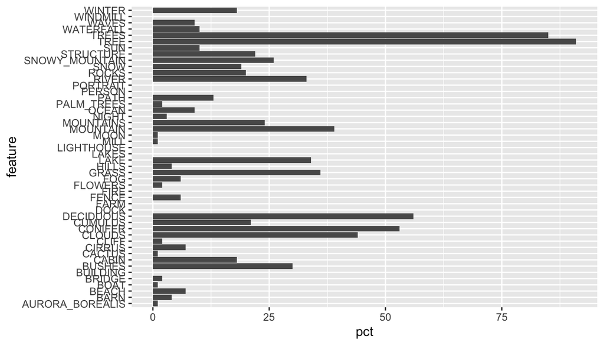

```r
ggplot(feature_counts, aes(x = pct, y = feature)) +
  geom_col()
```

- change the order of the features

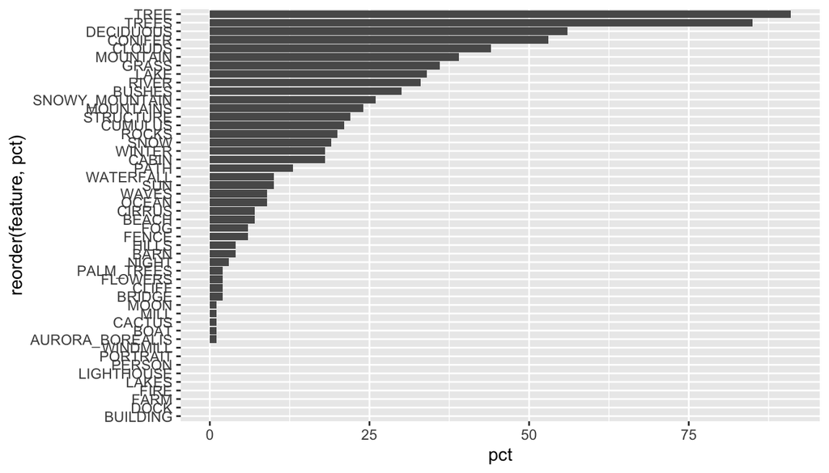

```r
ggplot(feature_counts, aes(x = pct,
                           y = reorder(feature, pct))) +
  geom_col()
```

- add better labels
- custom theme (complicated)

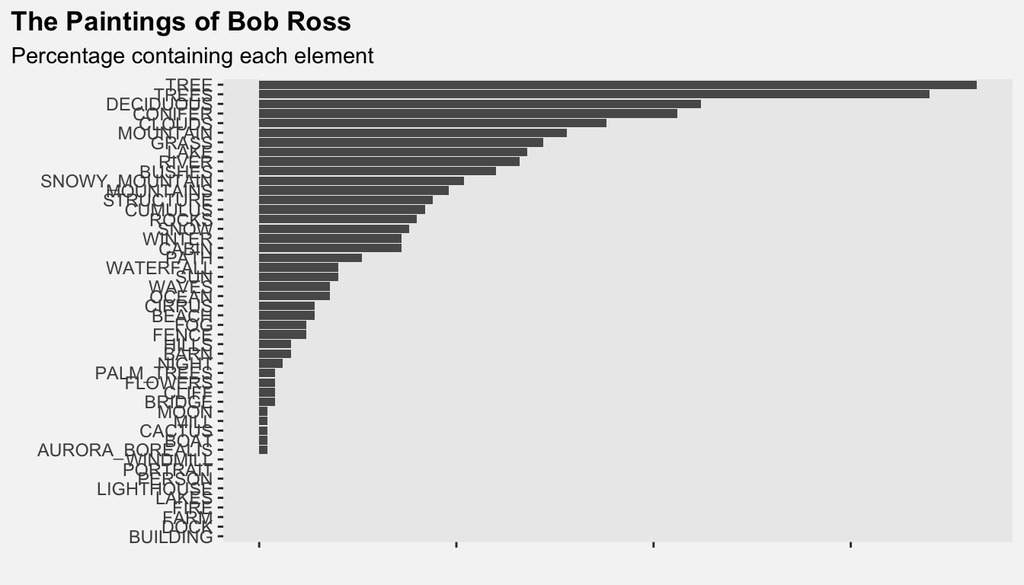

```r
ggplot(feature_counts, aes(x = pct,
                           y = reorder(feature, pct))) +
  geom_col() +
  labs(
    title = "The Paintings of Bob Ross",
    subtitle = "Percentage containing each element",
    x = "",
    y = ""
  ) +
  ### lots of control, hard to learn
  theme(
    panel.grid = element_blank(),
    axis.text.x = element_blank(),
    plot.background = element_rect(fill = "gray96", color = "gray96"),
    plot.title.position = "plot",
    plot.title = element_text(face = "bold")
  )
```

- filter for pct >= 2
- add % numbers

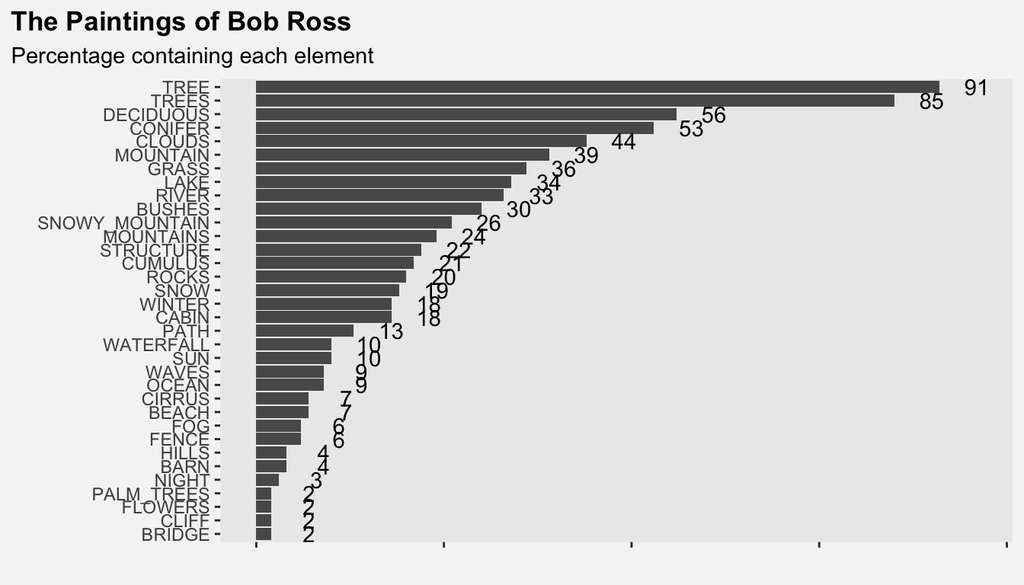

```r
feature_counts %>%
  filter(pct > 1) %>%
ggplot( aes(x = pct,
                           y = reorder(feature, pct))) +
  geom_col() +
  ### See solution in notes for a better way!
  geom_text(aes(x = pct + 5, label = pct)) +
  labs(
    title = "The Paintings of Bob Ross",
    subtitle = "Percentage containing each element",
    x = "",
    y = ""
  ) +
  ### lots of control, hard to learn
  theme(
    panel.grid = element_blank(),
    axis.text.x = element_blank(),
    plot.background = element_rect(fill = "gray96", color = "gray96"),
    plot.title.position = "plot",
    plot.title = element_text(face = "bold")
  )
```

- Even more can be done;;; see the notes

### Painting Colors

- New data with the colors used in each episode

#### Read the data

```r
painting_colors = read_csv("../../data/bob_ross_paintings.csv")
```

### Visualize num_colors

- histogram
  - always specify `binwidth` and either `boundary` or `center`
  - also good to specify `color` (edge color) and `fill` (interior color)

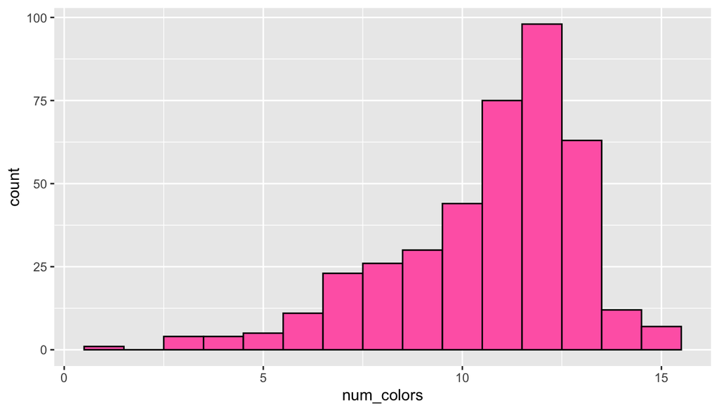

```r
ggplot(painting_colors, aes(x = num_colors)) +
  geom_histogram(center = 1, binwidth = 1,
                 color = "black", fill = "hotpink")
```

### Join data sets

- Add `season` and `episode` columns to `painting_elements`
- Then, `left_join()` with `painting_colors`

```r
## Add season and episode using str_sub()

painting_elements = painting_elements %>%
  mutate(season = as.numeric(str_sub(EPISODE, 2, 3)),
         episode = as.numeric(str_sub(EPISODE, 5, 6))) %>%
  relocate(season, episode, .before = EPISODE)

temp_colors = painting_colors %>%
  select(season, episode, painting_title, num_colors,
         Black_Gesso:Alizarin_Crimson)

ross = painting_elements %>%
  left_join(temp_colors, join_by(season, episode)) %>%
  relocate(painting_title, num_colors,
           .after = TITLE) %>%
  select(-TITLE) %>%
  rename(ID = EPISODE)
```

### Inference

- 95% CI for paintings with a man-made structure

```r
prob1 = ross %>%
  summarize(n = n(),
            ntilde = n+4,
            x = sum(STRUCTURE),
            xtilde = x+2,
            phat = x/n,
            ptilde = xtilde/ntilde,
            se = sqrt(ptilde * (1 - ptilde) / ntilde),
            z_crit = qnorm(0.975),
            moe = z_crit * se,
            low = ptilde - moe,
            high = ptilde + moe)

prob1 %>%
  print(width = Inf)
```

```
## # A tibble: 1 × 11
##       n ntilde     x xtilde  phat ptilde     se z_crit    moe   low  high
##   <int>  <dbl> <dbl>  <dbl> <dbl>  <dbl>  <dbl>  <dbl>  <dbl> <dbl> <dbl>
## 1   381    385    84     86 0.220  0.223 0.0212   1.96 0.0416 0.182 0.265
```

```r
prob1 %>%
  select(low, high) %>%
  as.data.frame()
```

```
##        low      high
## 1 0.181772 0.2649813
```

- 95% HT for $p$, the hypothetical population proportion of paintings with a man-made structure.

$H_0: p = 0.2$  
$H_a: p \neq 0.2$

If $H_0$ is true, then $X \sim \text{Binomial}(381, 0.2)$.

The observed statistic is $x = 84$.

Compare to the binomial distribution:

$\mathsf{E}(X) = 381 \times 0.2 \doteq 76.2$

```r
expected = 381*0.2
expected
```

```
## [1] 76.2
```

$\mathsf{SE}(X) = \sqrt{ 381 \times 0.2 \times 0.8} \doteq 7.8$

```r
se = sqrt(381*0.2*0.8)
se
```

```
## [1] 7.807689
```

- The observed $x = 84$ is about 1 SE above the mean, which is not unusual.
- Calculate the two-sided p-value by finding $P(X \ge 84)$ for the right tail and $P(X \le 68)$ for the left tail.
  - The notes has a likelihood-based method to determine the cutoff of the left tail.
  - A short cut is $x=84$ is 7.8 above the mean, the mean 76.2 minus 7.8 is 68.4, so any result 68 or lower is more extreme than the observed $x=84$.
- Calculate p-value from direct binomial probability calculation

```r
p_value = 1 - pbinom(83, 381, 0.2) + pbinom(68, 381, 0.2)
p_value
```

```
## [1] 0.3364916
```

> The data is consistent with the null hypothesis $p=0.2$, that the long-run proporiton of times Bob Ross includes a man-made structure in his TJOP paintings equals 0.2, (p-value = 0.33, two-sided binomial test for $p$).

OR

> There is a lack of sufficient statistical evidence to conclude that the long-run proporiton of times Bob Ross includes a man-made structure in his TJOP paintings is not equal to 0.2, $p \neq 0.2$, (p-value = 0.33, two-sided binomial test for $p$).